# Fitting a line to data

## The correlation coefficient

To explain how to compute and interpret the correlation coefficient, we’ll use the averages of the two variables to separate the UNICEF data into quadrants. Here’s the modified scatterplot:

```r
( x.bar <- mean(africa$Literacy) )
```

```
[1] 74.95745
```

```r
( y.bar <- mean(africa$IMR) )
```

```
[1] 58.10638
```

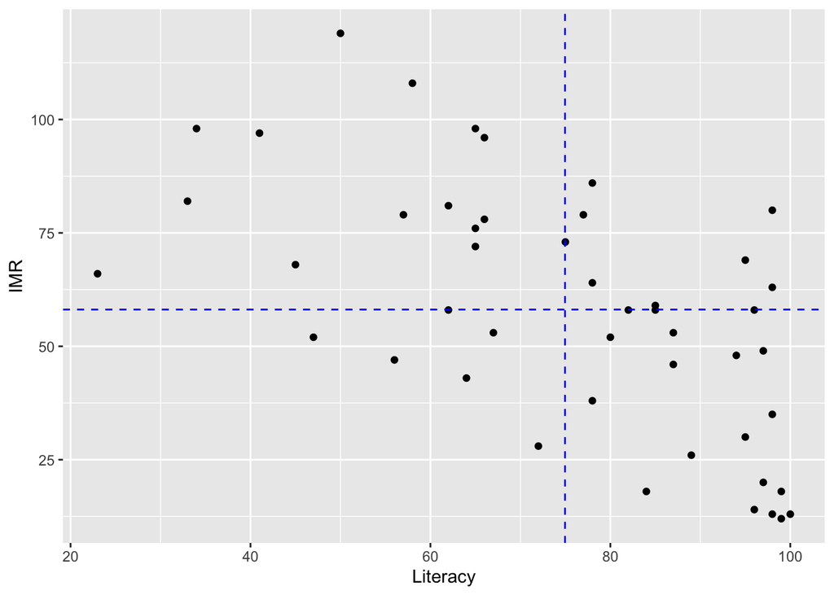

```r
africa.plot +
  geom_vline(xintercept=x.bar,linetype="dashed",color="blue") +
  geom_hline(yintercept=y.bar, linetype="dashed",color="blue")
```

If we compare the coordinates of each point with the corresponding averages, looking specifically at the *sign* of each deviation from the average, we get the following breakdown by quadrant:

| Quadrant | `Literacy` coordinate | `Literacy` deviation | `Deaths` coordinate | `Deaths` deviation | Product of deviations |
| --- | --- | --- | --- | --- | --- |
| Upper right | Above average | Positive | Above average | Positive | Positive |
| Upper left | Below average | Negative | Above average | Positive | Negative |
| Lower left | Below average | Negative | Below average | Negative | Positive |
| Lower right | Above average | Positive | Below average | Negative | Negative |

We see a negative association in the UNICEF data precisely because most of the points – more than 2/3 of them – are in the upper left and lower right quadrants; most of the products of the deviations of their coordinates from their respective averages are therefore negative. The signs of these products encode how the coordinates vary together – positive products when they increase together, negative products when they change in opposite ways. The correlation coefficient is an average of these products, normalized as shown below, so the correlation between `Literacy` and `IMR` is negative. To determine its precise value, use R’s `cor()` function:

```r
(africa.r <- cor(africa$Literacy, africa$IMR))
```

```
[1] -0.6162219
```

The correlation between `Literacy` and `IMR` is about -0.62, an indicator of a fairly strong linear relationship; for comparison, the correlation between the heights of fathers and sons is about 0.5. Before getting into how to interpret these values, let’s summarize the gross properties of the correlation between two quantitative variables, using the quadrants determined by their averages for reference:

- If most of the points in a scatterplot are in the upper right and lower left quadrants, the correlation coefficient will be positive.
- If most of the points in a scatterplot are in the upper left and lower right quadrants, the correlation coefficient will be negative.
- If the points in a scatterplot are all over the place, the correlation will be close to zero.

The sign of the correlation therefore corresponds to the linear trend – positive, negative, or none – shown in the scatterplot of the data. As for its numerical value, here are the main things to know:

- The correlation coefficient is *dimensionless*; unlike summary statistics like the average and the standard deviation, it has no units.
- The correlation coefficient is *not* a percentage – don’t ever report it as such!
- The correlation coefficient is between -1 and +1.
- The stronger the positive linear relationship is between two quantitative variables, the closer the correlation coefficient is to +1.
- The stronger the negative linear relationship is between two quantitative variables, the closer the correlation coefficient is to -1.
- The weaker the linear relationship is between two quantitative variables, the closer the correlation coefficient is to 0.

Genuine linear relationships in real data often yield correlations between .3 and .7 in absolute value, so don’t expect to see correlations really close to the extremes of +1 or -1. A correlation of +1 only happens if all of the data lie on a line of positive slope; a correlation of -1 only happens if all of the data lie on a line of negative slope. We will work through a real example below in which the correlation is very close to +1, but that is highly unusual! Interpreting correlations gets easier with experience, but always remember that the correlation coefficient measures the strength of a linear relationship – using it for anything else is just wrong.

#### Computing the correlation coefficient

First, don’t compute the correlation by hand, not that you should ever be tempted to do so! It’s good to know and understand the formula, but let your favorite implementation of it take care of the calculation. With that disclaimer out of the way, here is the explicit formula for $r$, the correlation coefficient:

$$r ~ = ~ \frac{1}{n-1} \, \sum_{x,y}{ \left( \frac{ x - \bar{x} }{s_{x}} \right) \left( \frac{ y - \bar{y} }{ s_{y} } \right) } \ .$$

In this formula, the sum includes all of the data points $(x,y)$,

- $\bar{x}$ is the average of the predictor variable,
- $\bar{y}$ is the average of the response variable,
- $s_{x}$ is the standard deviation of the predictor variable, and
- $s_{y}$ is the standard deviation of the response variable.

Observe how the correlation coefficient averages the product of the *z-scores* of the coordinates of all of the data points – this can be a handy way to remember and think about this formula.